# Hypothesis Tests

Author

Affiliation

Undergrad Hernandes Peres

[Biometrics Lab.](https://biometria.ufv.br/)

### 1. Clean up the environment

```r
rm(list=ls())  # Remove any previously created objects
ls()           # Check the objects in the current R session
```

```
character(0)
```

### 2. Installing and loadind packages

```r
# install.packages(c("ggplot2", "dplyr"))

library(ggplot2)
library(dplyr)
```

### 3. Save and load results

Save created objects

```r
save(list = ls(all.names = TRUE), file = "Result.RData", envir = .GlobalEnv)
```

Load saved file after exiting R

```r
load("Result.RData", envir = parent.frame(), verbose = FALSE)
```

Check objects in the “Result.RData” file

```r
ls()
```

```
character(0)
```

## Example 1: F-test for Variance

An F-test is used to determine whether two populations have equal variances. In terms of hypothesis testing, we have:

- $H_0: \sigma_1^2 = \sigma_2^2$
- $H_{a1}: \sigma_1^2 > \sigma_2^2, \quad \text{or}$
- $H_{a2}: \sigma_1^2 < \sigma_2^2, \quad \text{or}$
- $H_{a3}: \sigma_1^2 \neq \sigma_2^2$

$$F_{\text{calc}} = \frac{s_1^2}{s_2^2}, \quad \text{where} \quad
F_{\text{calc}} \sim F_{\alpha}(n_1 - 1, n_2 - 1)$$

“The quality of bricks is considered better when their homogeneity is higher. Six bricks from two brands were tested for shear strength, and rupture forces were measured. The producer of Brand B claims their bricks are better. Use a 5% significance level.”

```r
brand_A <- c(34.9, 35.5, 38.8, 39.2, 33.7, 37.6)
brand_B <- c(38.5, 39.0, 40.7, 42.9, 37.8, 41.4)

var(brand_A)
```

```
[1] 5.021667
```

```r
var(brand_B)
```

```
[1] 3.787
```

**a) F-test for variances**

```r
var.test(brand_A, brand_B, ratio = 1, alternative = "greater", conf.level = 0.95)
```

```
    F test to compare two variances

data:  brand_A and brand_B
F = 1.326, num df = 5, denom df = 5, p-value = 0.3822
alternative hypothesis: true ratio of variances is greater than 1
95 percent confidence interval:
 0.2625626       Inf
sample estimates:
ratio of variances
          1.326028
```

Another way to calculate the p-value

```r
pf(1.326, df1 = 5, df2 = 5, lower = FALSE, log.p = FALSE)
```

```
[1] 0.3821979
```

## Example 2: t-test for single mean

Usually T-test is used to verify a population mean, when it assume a especific value.

- $H_0: \mu = k;$
- $H_{a1}: \mu > k, \quad \text{or}\\$
- $H_{a2}: \mu < k, \quad \text{or}\\$
- $H_{a3}: \mu \neq k$

Then utilizing the formula:
$$t_{\text{calc}} = \frac{\hat{\mu} - \mu}{\frac{s}{\sqrt{n}}}, \quad \text{where} \quad t_{\text{calc}} \sim t_{\alpha(n-1)}$$
“In healthy individuals, renal oxygen consumption is normally distributed around 12 cm³/min.We want to test if a certain disease affects this value using data from five patients. Test at a 1% significance level.”

```r
o2 = data.frame(v1 = as.factor(1),
                v2 = c(14.4, 12.9, 15.0, 13.7, 13.5))
```

Using the `t.test()` function, we can perform a t-test for a mean when the argument paired is set to `FALSE`.

```r
t = t.test(o2$v2,
           mu = 12,
           paired = FALSE,
           alternative = "two.sided",
           conf.level = 0.99);t
```

```
    One Sample t-test

data:  o2$v2
t = 5.2099, df = 4, p-value = 0.006472
alternative hypothesis: true mean is not equal to 12
99 percent confidence interval:
 12.22093 15.57907
sample estimates:
mean of x
     13.9
```

Another way to calculate the **p-value** is by using the `pt()` function, providing the test statistic, degrees of freedom, and multiplying by 2, since it is a two-tailed test.

```r
pt(5.2099, df = 4, lower = FALSE) * 2
```

```
[1] 0.006472066
```

$\text{Why we multiply by 2?}$

The term `pt(5.2099, df = 4, lower = FALSE)` calculates the **upper-tail probability** (p-value) for a t-statistic of 5.2098807 with 4 degrees of freedom.

Then, multiplying this by 2 gives a two-tailed p-value, which accounts for both extremes (positive and negative) of the t-distribution.

We can also access the values by referring to the object `t` created when using `t.test()`.

When manipulating data, another way to access specific values, besides using the `$` operator, is by using double square brackets `[[]]`.

```r
pt(t[[1]], df = t[[2]], lower = F) * 2
```

```
          t
0.006472151
```

Repeat the test with a 95% confidence interval

```r
teste_t <- t.test(o2$v2,
                  mu = 12,
                  paired = FALSE,
                  alternative = "two.sided",
                  conf.level = 0.95);teste_t
```

```
    One Sample t-test

data:  o2$v2
t = 5.2099, df = 4, p-value = 0.006472
alternative hypothesis: true mean is not equal to 12
95 percent confidence interval:
 12.88745 14.91255
sample estimates:
mean of x
     13.9
```

**b) Boxplot for the sample**

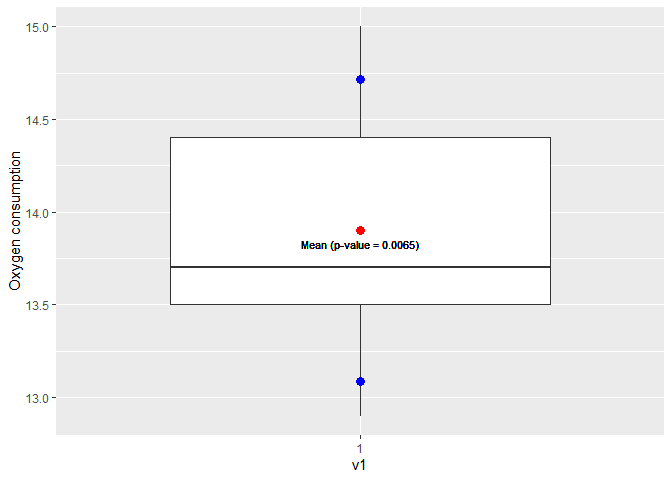

```r
mean_v2 <- mean(o2$v2)
sd_v2 <- sd(o2$v2)

ggplot(o2, aes(x = v1, y = v2)) +
  geom_boxplot() +
  geom_point(aes(y = mean(v2)), color = "red", size = 3) +
  geom_text(aes(y = mean(v2), label = "Mean (p-value = 0.0065)"),
            color = "black", size = 3, vjust = 2) +
  geom_point(aes(y = mean(v2) + sd(v2)), color = "blue", size = 3) +
  geom_point(aes(y = mean(v2) - sd(v2)), color = "blue", size = 3) +
  labs(y = "Oxygen consumption")
```

## Example 3: t-test for two independent means (Case A)

The main goal of this test is to determine whether two populations share the same mean value for a determinate trait; in other words, we aim to verify if $\mu_1 = \mu_2$.

The two samples can be:

- $\text{Dependents or paired}$
- $\text{Independent or unpaired (case A and case B)}$

Before performing the t-Test, we must first apply the F-test to verify whether the variances of the two populations are equal. This will help determine which case to follow:

- **Case A** – Variances are equal
- **Case B** – Variances are not equal

Data represents the strength of two types of concrete. At a 5% significance level, we want to test if concrete 1 is stronger than concrete 2.

```r
c1 <- c(54, 55, 58, 51, 57)
c2 <- c(50, 54, 56, 52, 53)
```

**a) Test for variance homogeneity**

```r
var(c1)
```

```
[1] 7.5
```

```r
var(c2)
```

```
[1] 5
```

```r
var.test(c1, c2, ratio = 1, alternative = "greater", conf.level = 0.95)
```

```
    F test to compare two variances

data:  c1 and c2
F = 1.5, num df = 4, denom df = 4, p-value = 0.352
alternative hypothesis: true ratio of variances is greater than 1
95 percent confidence interval:
 0.2348067       Inf
sample estimates:
ratio of variances
               1.5
```

**b) Conduct the t-test**

Once the **p-value** is 0.352, the variance of the two population are equal, we can follow the equation to calculate the common variance:

$$t_{calc} = \frac{(\hat{\mu}_1 - \hat{\mu}_2) - (\mu_1 - \mu_2)}{\sqrt{s_c^2 \left( \frac{1}{n_1} + \frac{1}{n_2} \right)}}, \quad \text{where} \quad
t_{tab} = t_{\alpha (n_1 + n_2 - 2)}$$
Where the $s_c^2$ is:
$$s_c^2 = \frac{(n_1 - 1)s_1^2 + (n_2 - 1)s_2^2}{n_1 + n_2 - 2}$$
Then, the hypothesis to be tested are:

- $H_0: \mu_1 = \mu_2 \quad (H_0:\mu_1-\mu_2=0);$
- $H_{a1}: \mu_1 > \mu_2, \quad \text{or} \\$
- $H_{a2}: \mu_1 < \mu_2, \quad \text{or} \\$
- $H_{a3}: \mu_1 \neq \mu_2$

```r
t <- t.test(c1, c2,
       mu = 0,
       paired = FALSE,
       var.equal = TRUE,
       alternative = "greater",
       conf.level = 0.95);t
```

```
    Two Sample t-test

data:  c1 and c2
t = 1.2649, df = 8, p-value = 0.1208
alternative hypothesis: true difference in means is greater than 0
95 percent confidence interval:
 -0.9402036        Inf
sample estimates:
mean of x mean of y
       55        53
```

**c) Plotting two samples test**

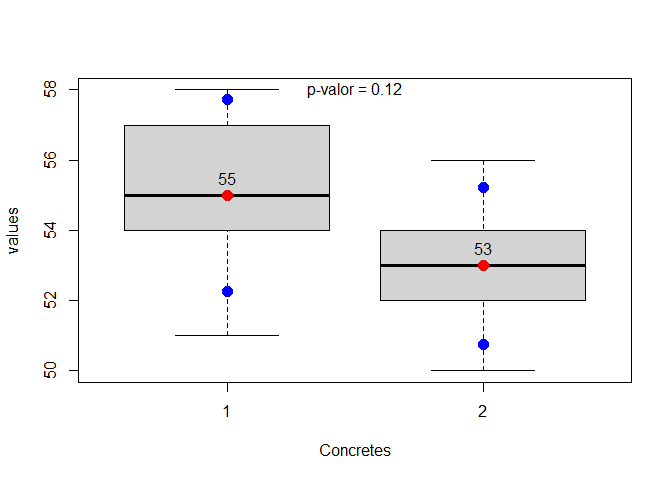

```r
df <- data.frame(name = as.factor(rep(1:2, each = 5)),
                values = c(c1,c2))

boxplot(values ~ name,
        data = df,
        border = "black",
        ylab = "values",
        xlab = "Concretes")

means <- tapply(df$values, df$name, mean)
sds   <- tapply(df$values, df$name, sd)

points(1:2, means, pch = 19, col = "red", cex = 1.5)
points(1:2, means + sds, pch = 19, col = "blue", cex = 1.5)
points(1:2, means - sds, pch = 19, col = "blue", cex = 1.5)

text(x = 1, y = 55.5, labels = "55", col = "black")
text(x = 2, y = 53.5, labels = "53", col = "black")
text(x = 1.5, y = 58, labels = paste0("p-valor = ", round(t$p.value, 2)))
```

## Example 4: t-test for two independent means (Case B)

To calculate the statistic for Case B, since the variances are differ between the populations, we use the following equation to compute it:

$$t_{calc} = \frac{(\hat{\mu}_L - \hat{\mu}_A) - (\mu_L - \mu_A)}{\sqrt{\frac{s_L^2}{n_L} + \frac{s_A^2}{n_A}}},
\quad \text{where} \quad
t_{\text{tab}}=t_{\alpha(n^*)}$$

When population variances are not considered equal according to the F-test, a **weighted degree of freedom** is required, which is calculated by

$$n^* = \frac{\left( \frac{s_1^2}{n_1} + \frac{s_2^2}{n_2} \right)^2}{\frac{\left( \frac{s_1^2}{n_1} \right)^2}{n_1 - 1} + \frac{\left( \frac{s_2^2}{n_2} \right)^2}{n_2 - 1}}$$

Comparing salaries of two professional groups: general **liberal professionals** and business **administration graduates**.

Test at a $\alpha=0.05$ significance level.

```r
lib <- c(6.6, 10.3, 10.8, 12.9, 9.2, 12.3, 7.0)
adm <- c(8.1, 9.8, 8.7, 10.0, 10.2, 10.8, 8.2, 8.7, 10.1)
```

```r
var(lib)
```

```
[1] 5.919048
```

```r
var(adm)
```

```
[1] 0.965
```

```r
var.test(lib,
         adm,
         ratio = 1,
         alternative = "greater",
         conf.level = 0.95)
```

```
    F test to compare two variances

data:  lib and adm
F = 6.1337, num df = 6, denom df = 8, p-value = 0.01122
alternative hypothesis: true ratio of variances is greater than 1
95 percent confidence interval:
 1.713054      Inf
sample estimates:
ratio of variances
          6.133728
```

```r
TST <- t.test(lib, adm,
              mu = 0,
              paired = FALSE,
              var.equal = FALSE,
              alternative = "two.sided",
              conf.level = 0.95)
TST
```

```
    Welch Two Sample t-test

data:  lib and adm
t = 0.48296, df = 7.5273, p-value = 0.6429
alternative hypothesis: true difference in means is not equal to 0
95 percent confidence interval:
 -1.804338  2.747195
sample estimates:
mean of x mean of y
 9.871429  9.400000
```

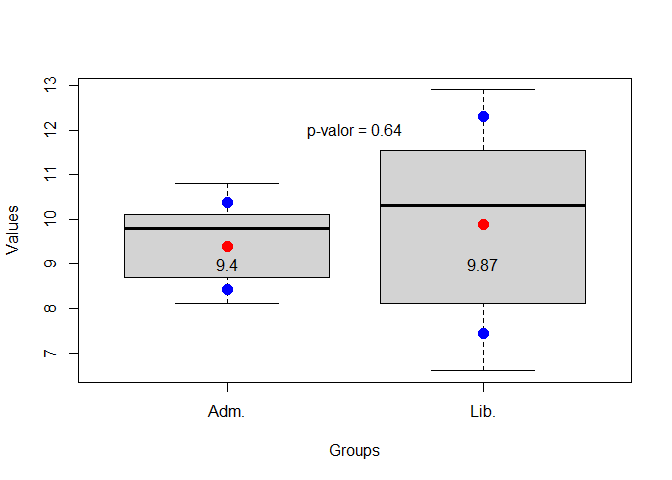

```r
df2 = data.frame(name = factor(rep(c("Lib.", "Adm."), c(7,9))),
                 values = c(lib, adm))

boxplot(values~name,
        data = df2,
        xlab = "Groups",
        ylab = "Values",
        border = "black",
        outline = TRUE)

means <- tapply(df2$values, df2$name, mean)
sds <- tapply(df2$values, df2$name, sd)

points(1:2, means, pch = 19, col = "red", cex = 1.5)
points(1:2, means + sds, pch = 19, col = "blue", cex = 1.5)
points(1:2, means - sds, pch = 19, col = "blue", cex = 1.5)

text(x = 1, y = 9, labels = "9.4", col = "black")
text(x = 2, y = 9, labels = "9.87", col = "black")
text(x = 1.5, y = 12, labels = paste0("p-valor = ", round(TST$p.value, 2)))
```

## Example 5: t-test for paired data (Before vs After) - Dependent

When working with a dependent sample, we aim to verify whether the mean of the differences is equal to zero. Therefore, the hypotheses are as follows:

- $H_0: \mu_d = k$
- $H_{a1}: \mu_d > k, \quad \text{or}$
- $H_{a2}: \mu_d < k, \quad \text{or}$
- $H_{a3}: \mu_d \neq k$

To calculate the statistic, we can use the formula:
$$t_{\text{calc}} = \frac{\hat{\mu}_d - \mu_d}{\frac{s_d}{\sqrt{n}}}
\quad \text{where} \quad
t_{\text{calc}} \sim t_{\alpha(n-1)}$$

We want to test if a chemical product is effective in repelling household insects. The number of insects was counted **before** and **after** the application of the product.

```r
before <- c(8, 6, 7, 8, 9, 6, 7)
after <- c(4, 0, 3, 5, 3, 4, 2)
```

**a) Testing for paired data**

As we can see from the other performed t-tests, here we set `paired` equal to `TRUE`.

```r
t.test(after, before, paired = TRUE, alternative = "less", conf.level = 0.95)
```

```
    Paired t-test

data:  after and before
t = -7.5794, df = 6, p-value = 0.0001371
alternative hypothesis: true mean difference is less than 0
95 percent confidence interval:
      -Inf -3.186953
sample estimates:
mean difference
      -4.285714
```

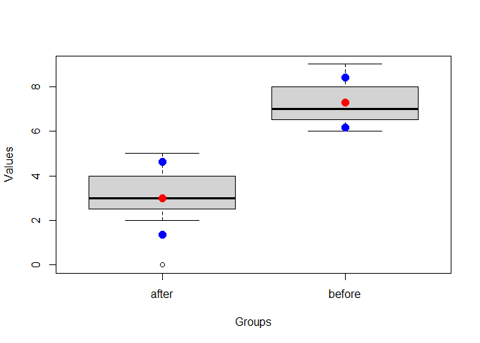

```r
df = data.frame(name = factor(rep(c("before", "after"),
                                  c(7, 7))),
                values = c(before, after))

boxplot(values ~name,
        data = df,
        xlab = "Groups",
        ylab = "Values",
        border = "black",
        outline = TRUE)

means <- tapply(df$values, df$name, mean)
sds <- tapply(df$values, df$name, sd)

points(1:2, means, pch = 19, col = "red", cex = 1.5)
points(1:2, means + sds, pch = 19, col = "blue", cex = 1.5)
points(1:2, means - sds, pch = 19, col = "blue", cex = 1.5)
```